# Measuring Media Slant through Image Analysis

Christian Arnold

University of Birmingham

**Andreas Küpfer**

Technical University of Darmstadt

Oliver Rittmann

University of Mannheim, MZES

Michelle Torres

University of California, Los Angeles

2026-06-18

## Images Dominate News Websites

[figure not shown]

New York Times, March 11, 2026

[figure not shown]

CNN, March 11, 2026

[figure not shown]

Bild, March 11, 2026

## The Same Event, Pictured Differently

[figure not shown]

AP News, June 1, 2024

[figure not shown]

Guardian, May 29, 2024

## Images Are Central in Modern Media Environments, Yet Unmeasured

- Images are omnipresent in news media, particularly online
- Images shape the perceptions of events, potentially more forcefully than text
- We know about textual media slant based, but what about visual reporting?
- Difficult to answer due to methodological hurdles

## This Study

# Framework

## Framework: Two Steps

> **Core assumption:** News outlets that are close to each other in the latent space will, on average, use more similar news imagery.
1. **Measurement of image similarity**: Encode each image with a pre-trained Vision Transformer (ViT)  
   → extract the `[CLS]` token embedding (512 dims)  
   → compute pairwise **cosine similarities** across all image dyads
2. **Statistical model to analyse image similarity**: Additive-Multiplicative Effects (AME) network model to recover latent positions of  
   (a) **media outlets** based on the news imagery used by them and  
   (b) **images** themselves

## Step 2: The AME Model

Additive-multiplicative effects *(Hoff 2005, 2021)* on outlet level:

$$\mathrm{atanh}\!\left(\mathrm{sim}(\vec{E}_i, \vec{E}_j)\right) = \mu + \alpha_{O_i} + \alpha_{O_j} + \vec{S}_{O_i}^\top \vec{S}_{O_j} + \epsilon_{ij}$$

$$\textcolor{lightgray}{\mathrm{atanh}\!\left(\textcolor{teal}{\mathrm{sim}(\vec{E}_i, \vec{E}_j)}\right) =} \textcolor{lightgray}{\mu + \alpha_{O_i} + \alpha_{O_j} + \vec{S}_{O_i}^\top \vec{S}_{O_j} + \epsilon_{ij}}$$

$$\textcolor{lightgray}{\mathrm{atanh}\!\left(\mathrm{sim}(\vec{E}_i, \vec{E}_j)\right)} = \textcolor{lightgray}{\mu} + \textcolor{lightgray}{\alpha_{O_i} + \alpha_{O_j}} + \textcolor{red}{\vec{S}_{O_i}^\top \vec{S}_{O_j}} + \textcolor{lightgray}{\epsilon_{ij}}$$

$\textcolor{teal}{\mathrm{sim}(\vec{E}_i, \vec{E}_j)}$ is the **cosine similarity** between the ViT embeddings of images $i$ and $j$.

$\vec{S}_{O_i}$: Latent position of outlet $O$ that posted image $i$  
$\vec{S}_{O_j}$: Latent position of outlet $O$ that posted image $j$

| Configuration | $S_i \cdot S_j$ | Predicted image similarity |
| --- | --- | --- |
| Same pole $(+,+)$ or $(-,-)$ | $>0$ | above baseline |
| Opposite poles $(+,-)$ | $<0$ | below baseline |

## Image-Level Model

Assign a position directly to each images rather than outlets:

$$\mathrm{atanh}\!\left(\mathrm{sim}(\vec{E}_i, \vec{E}_j)\right) = \mu + \textcolor{red}{\vec{S}_i^\top \vec{S}_j} + \epsilon_{ij}, \quad \epsilon_{ij} \sim \mathcal{N}(0,\sigma^2)$$

$\vec{S}_i$ **Latent scale position of image $i$**

- Estimated in a Bayesian framework
- No labelled data required

# Case Study: Gaza War, 2023–2024

## Data: Visual Reporting on the Gaza War

**Corpus**

> **Leading Question:** Can we recover media slant *exclusively* based on news imagery?

# Results

## Outlet-Level Visual Slant

[figure not shown]

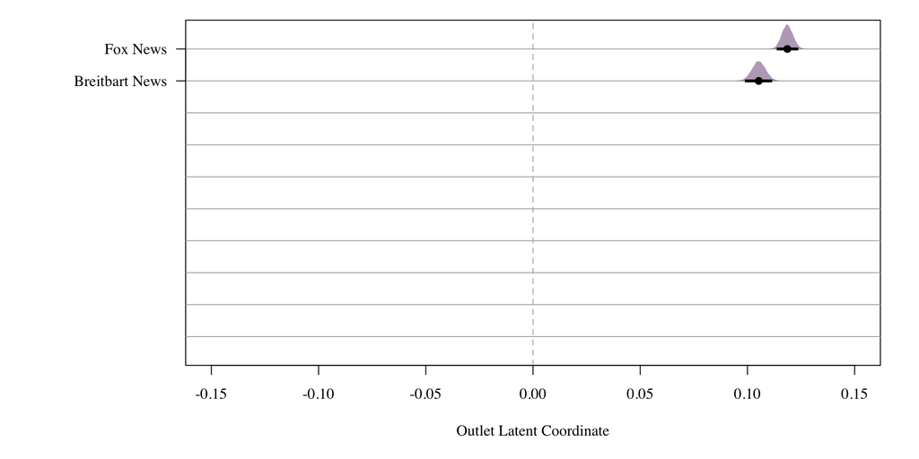

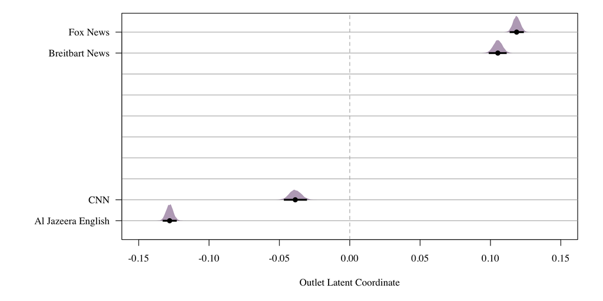

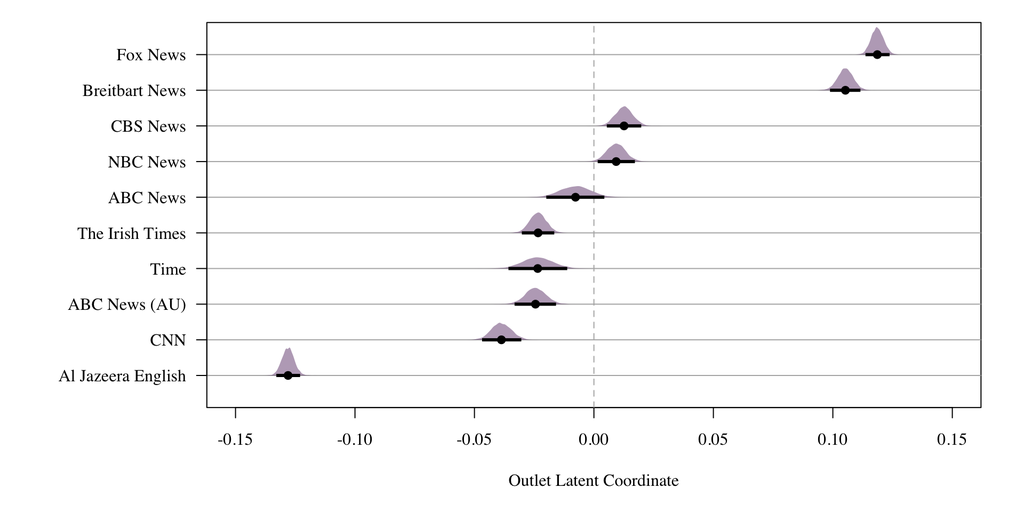

## Image-Level: What Is on the Scale?

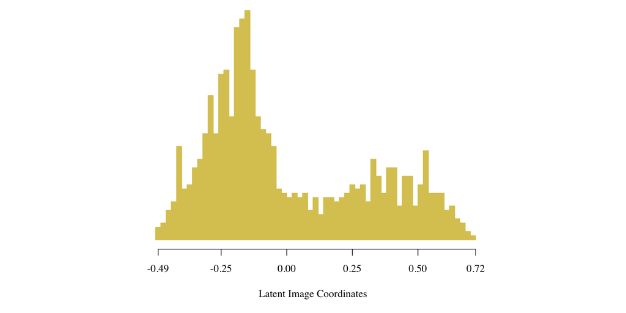

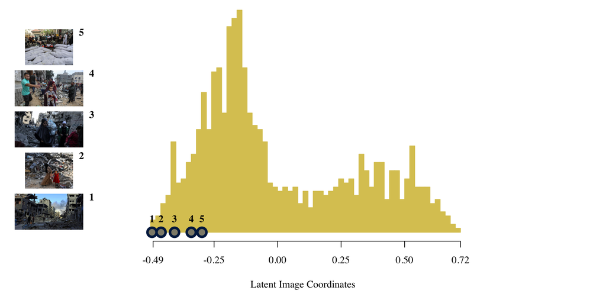

[figure not shown]

## Is Visual Slant Just Downstream of Text Slant?

> **Concern:** Do outlets differ in *which stories* they cover (text) or in *how they picture the same story*?

**Design:** within each day, match articles across two outlets on text-embedding similarity (adapting *Roberts et al. 2020*) and compare images attached to textually similar reports

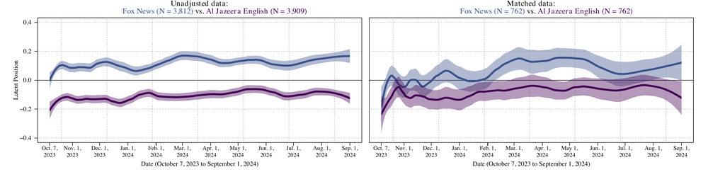

Separation narrows but persist across outlet pairs: visual slant reflects deliberate image selection, not merely topic coverage

# Conclusion

## Conclusion and Future Directions

**Contribution**

- Scalable framework for recovering latent positions from visual corpora
- Method to measure visual slant in news media

**Findings on Gaza War coverage**

- Far-right outlets share a distinctive visual repertoire; Al Jazeera diverges sharply
- Scale captures a substantively meaningful dimension: elite framing vs. humanitarian suffering
- Visual slant persists after matching on text

Measuring Media Slant through Image Analysis

Christian Arnold · Andreas Kuepfer · Oliver Rittmann · Michelle Torres

**Contact:**  
andreaskuepfer.github.io  
andreas.kuepfer@tu-darmstadt.de  
ankuepfer@bsky.social

# Appendix

## Appendix: Dynamic Visual Slant: Stable Sorting, Parallel Dynamics

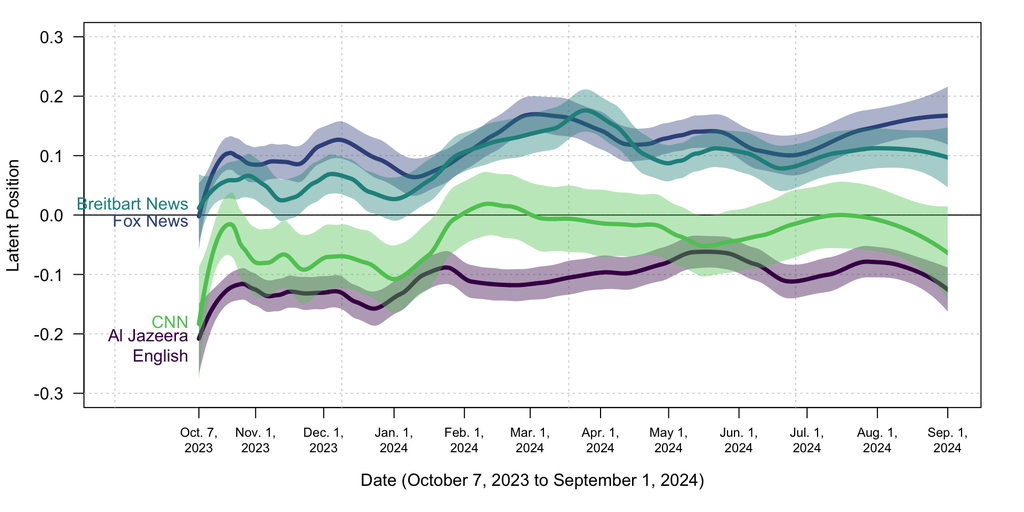

## Appendix: Visual Slant Conditional on Text — All Pairs

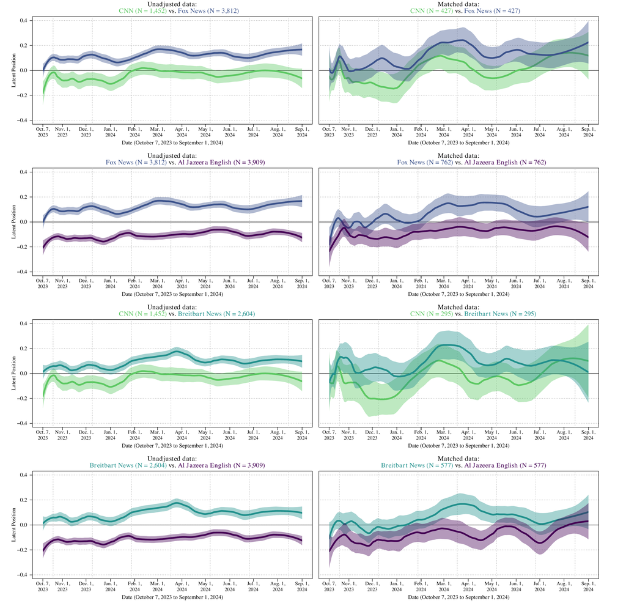

*Left:* all images per outlet. *Right:* within-day, text-matched article pairs. Separation attenuates but persists.

## Appendix: Text-Matching Design

Adapting Roberts et al. (2020) to isolate visual framing from textual content:

1. Restrict to articles published by both outlets **on the same day**
2. Compute pairwise cosine distances on **768-dim text embeddings**
3. **Greedy 1:1 nearest-neighbour** matching across the two outlets
4. Impose a **caliper** (max permissible distance) — drop insufficiently similar pairs

> Remaining variation in image position between outlets is then attributable to **editorial image selection**, not differences in topic coverage.

## Appendix: Text-Matched Differences (Table 1)

[output not shown]

OLS of latent image position on outlet, day fixed effects, within-day matched sample.

## Appendix: Images per Outlet

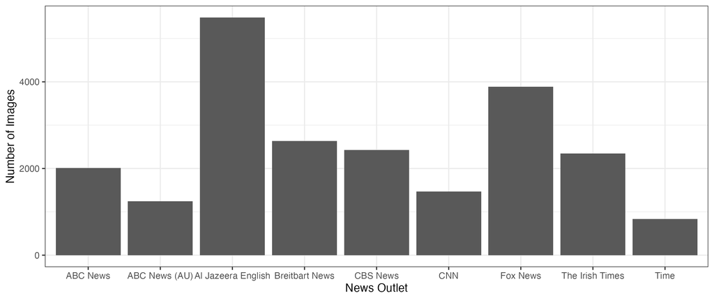

## Appendix: Images per Outlet over Time

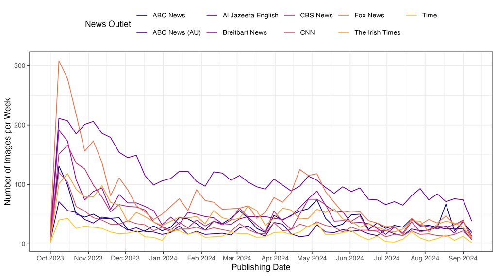

## Appendix: Step 2: The AME Model

Additive-multiplicative effects *(Hoff 2005, 2021)* — outlet level:

$$\textcolor{lightgray}{\mathrm{atanh}\!\left(\mathrm{sim}(\vec{E}_i, \vec{E}_j)\right)} = \textcolor{blue}{\mu} + \textcolor{lightgray}{\alpha_{O_i} + \alpha_{O_j}} + \textcolor{lightgray}{\vec{S}_{O_i}^\top \vec{S}_{O_j}} + \textcolor{lightgray}{\epsilon_{ij}}$$

$\mu$ is the **global baseline** similarity of news imagery across outlet pairs.

## Appendix: Step 2: The AME Model

Additive-multiplicative effects *(Hoff 2005, 2021)* — outlet level:

$$\textcolor{lightgray}{\mathrm{atanh}\!\left(\mathrm{sim}(\vec{E}_i, \vec{E}_j)\right)} = \textcolor{lightgray}{\mu} + \textcolor{orange}{\alpha_{O_i} + \alpha_{O_j}} + \textcolor{lightgray}{\vec{S}_{O_i}^\top \vec{S}_{O_j}} + \textcolor{lightgray}{\epsilon_{ij}}$$

$\alpha_{O_i}$: Random effects for outlet $O$ that posted image $i$.

$\alpha_{O_j}$: Random effects for outlet $O$ that posted image $j$.